# Application de méthodes de régression en statistique

Exemples en R

9 février 2019

```r
library(nycflights13)  # données vols d'avion
library(car)           # fonction Anova (tests globaux variables catégoriques)
library(olsrr)         # fonction ols_step_all_possible
library(glmnet)        # lasso
```

# Présentation des données

Nous allons analyser des données concernant des vols d’avions. Nous allons tenter de cerner quelles variables ont une influence sur les retards dans les arrivées des vols.

Les données sont distribuées dans le package R `nycflights13`. Le jeu de données `flights` contient des informations sur tous les vols intérieurs qui sont partis d’un aéroport de la région de New York en 2013. Les trois aéroports de la région de New York sont John F Kennedy Intl (`JFK`), Newark Liberty Intl (`EWR`) et La Guardia (`LGA`).

```r
airports[airports$faa %in% unique(flights$origin), ]
```

```
## # A tibble: 3 x 8
##   faa   name                  lat   lon   alt    tz dst   tzone
##   <chr> <chr>               <dbl> <dbl> <int> <dbl> <chr> <chr>
## 1 EWR   Newark Liberty Intl  40.7 -74.2    18    -5 A     America/New_York
## 2 JFK   John F Kennedy Intl  40.6 -73.8    13    -5 A     America/New_York
## 3 LGA   La Guardia           40.8 -73.9    22    -5 A     America/New_York
```

Intéressons-nous aux vols en direction de l’aéroport General Edward Lawrence Logan Intl (`BOS`) de Boston pendant le mois de juillet.

[figure not shown]

## Variables mesurées

Description des variables selon la documentation officielle du package `nycflights13` (extrait de cette documentation, voir `help(flights)`, `help(planes)` et `help(weather)` pour les versions originales).

Variable réponse $Y$ :

- `arr_delay` : Arrival delays, in minutes. Negative times represent early departures/arrivals

Variables explicatives potentielles (présélection) :

- `dep_delay` : Departure delays, in minutes. Negative times represent early departures/arrivals
- `carrier` : Two letter carrier abbreviation. See `airlines` to get name
- `origin` : Origin. See `airports` for additional metadata
- `time_hour` : Scheduled date and hour of the flight -> *Nous allons en tirer les variables `week_day`, puis `wknd`*.
- `hour` : Hour of scheduled departure
- `seats` : Number of seats
- `dewp` : Dewpoint in F
- `humid` : Relative humidity
- `wind_dir` : Wind direction (in degrees) -> *Nous allons en tirer les variables `wind_sin` et `wind_cos`*.
- `wind_speed` : speed (in mph) -> *Nous allons en tirer les variables `wind_sin` et `wind_cos`*.
- `precip` : Preciptation, in inches -> *Nous allons en tirer l’indicatrice `precip_indic`*.
- `pressure` : Sea level pressure in millibars
- `visib` : Visibility in miles

## Préparation du jeu de données

Nous allons d’abord créer un jeu de données contenant uniquement les vols qui nous intéressent (destination = `BOS` et mois = 7). Puis, ajoutons à ce jeu de données de nouvelles variables :

- nombre de sièges dans l’avion, tiré du jeu de données `planes`;
- variables concernant la météo au moment du départ du vol, à l’aéroport d’origine, tirées du jeu de données `weather`;
- quelques nouvelles variables obtenues par transformation d’autres variables (expliquées plus loin).

```r
# Vols en direction de Boston en juillet
BOS <- subset(flights, subset = dest == "BOS" & month == 7)

# Ajout du nombre de sièges dans l'avion
BOS <- merge(x = BOS,
             y = subset(planes, select = c(tailnum, seats)),
             by = "tailnum", all.x = TRUE, all.y = FALSE)

# Ajout de variables météo
BOS <- merge(x = BOS,
             y = subset(weather, select = c(origin, time_hour, dewp, humid, wind_dir, wind_speed, precip, pressure, visib)),
             by = c("origin", "time_hour"), all.x = TRUE, all.y = FALSE)

# Ajout de nouvelles variables créées par transformation d'autres variables :
# - jour de la semaine du départ du vol
BOS$week_day <- weekdays(BOS$time_hour)

# - indicatrice de la fin de semaine (TRUE pour un vol de fin de semaine, FALSE sinon)
# Selon la langue d'installation de R, vous devez soit rouler la ligne en français ou celle en anglais.
BOS$wknd <- BOS$week_day %in% c("samedi", "dimanche")
#BOS$wknd <- BOS$week_day %in% c("Saturday", "Sunday")

# - indicatrice de l'heure de pointe de fin de journée
#   (TRUE si le vol a décolé entre 17 et 19 heures du soir, FALSE sinon)
BOS$evening_rush_hour <- (BOS$hour %in% c(17, 18))

# - variables pour représenter correctement modéliser les vents
BOS$wind_sin <- BOS$wind_speed*sin(BOS$wind_dir*pi/180)
BOS$wind_cos <- BOS$wind_speed*cos(BOS$wind_dir*pi/180)

# - indicatrice de la présence de précipitation (TRUE s'il y a des précipitations, FALSE sinon)
BOS$precip_indic <- BOS$precip > 0

# On ne conserve que les lignes avec aucune donnée manquante, pour les besoins de notre exemple.
BOS <- BOS[complete.cases(BOS),]
```

### Données test

Avant de commencer, mettons tout de suite de côté un sous-ensemble des données pour tester la qualité des prévisions obtenues de nos modèles. Nous formons donc une base de données test. Ce sous-ensemble est obtenu en sélectionnant de façon complètement aléatoire 20% des vols dans les données. Nous ne formons pas de base de données de validation. Si nous avons besoin de données de validation, par exemple pour déterminer des valeurs d’hyperparamètres, nous procéderons par validation croisée.

```r
# Sélection aléatoire de 20% des observations
set.seed(27) # pour avoir des résultats réplicables
index_test <- sample.int(n = nrow(BOS), size = 0.2*nrow(BOS))
# Données test
BOStest <- BOS[index_test, ]
# Données d'entrainement
BOStrain <- BOS[-index_test, ]
```

Ainsi, les 1029 vols au total sont divisés en 824 vols pour l’entraînement des modèles, 205 vols pour tester la performance prédictive des modèles.

## Objectifs

Les objectifs de l’analyse de données sont les suivants : - identifier les facteurs (variables) influençant les retards à l’arrivée, pour mieux comprendre les causes potentielles des retards ; - développer un modèle capable de prédire les temps de retard à l’arrivée juste après le décollage du vol (temps de retard du départ connu).

Nous mesurerons la qualité de la prédiction de la variable numérique `arr_delay` avec la racine carrée de l’erreur quadratique moyenne de prédiction. Voici une fonction pour calculer cet indice.

```r
RMSEp <- function(obs, pred){
  sqrt(mean((obs - pred)^2, na.rm = TRUE))
}
```

**Exercice.** Exécutez toutes les lignes de code ci-haut en vérifiant qu’aucun message d’erreur n’est obtenu. Utilisez la fonction `dim` pour voir les dimensions des bases de données `BOStrain` et `BOStest`.

# Analyse préliminaire des données

Avant de commencer l’analyse, il est important de se familiariser avec le contenu de la base de données d’entrainement, `BOStrain`.

**Exercice.** Utilisez la fonction `summary` pour obtenir les statistiques descriptives de chaque variable de `BOStrain`. Remarquez les différents types de variables: continues, booléen, catégorielles.

Évidemment, `arr_delay` est fortement relié à `dep_delay`, comme on peut le voir dans le graphique en nuage de points ci-dessous. Ce type de graphique est approprié lorsque la variable exogène est aussi continue.

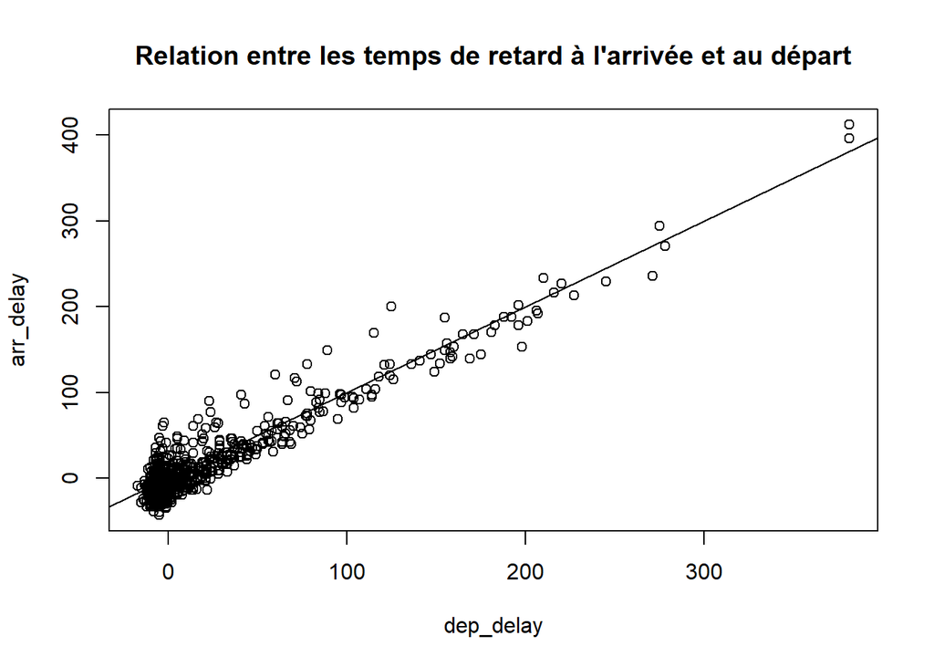

```r
plot(arr_delay ~ dep_delay, data = BOStrain,
     main = "Relation entre les temps de retard à l'arrivée et au départ")
abline(a = 0, b = 1)
```

Nous souhaitons comprendre quelles autres variables influencent `arr_delay`. Pour explorer cette question, produisons quelques graphiques représentant la relation entre l’écart `arr_delay - dep_delay` et certaines variables explicatives disponibles. Cette différence entre le temps de retard à l’arrivée et celui au départ est l’écart entre la durée prévue du vol et sa durée réelle (déviation de durée).

Comme on peut le voir dans le diagramme à moustache ci-dessous, certaines compagnies aériennes semblent avoir plus souvent des arrivées en retard que d’autres. Ce type de graphique est approprié lorsque la variable exogène est catégorielle.

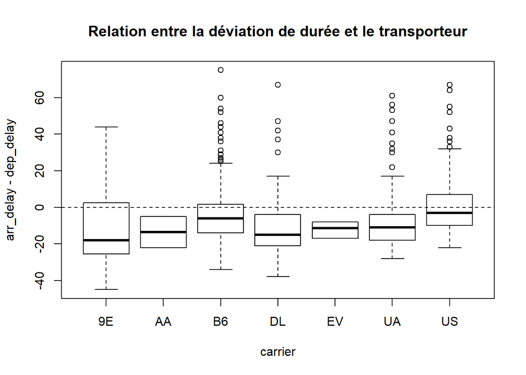

```r
boxplot(arr_delay - dep_delay ~ carrier, data = BOStrain,
        ylab = "arr_delay - dep_delay", xlab = "carrier",
        main = "Relation entre la déviation de durée et le transporteur")
abline(h = 0 , lty = 2)
```

```r
airlines[airlines$carrier %in% unique(BOStrain$carrier), ]
```

```
## # A tibble: 7 x 2
##   carrier name
##   <chr>   <chr>
## 1 9E      Endeavor Air Inc.
## 2 AA      American Airlines Inc.
## 3 B6      JetBlue Airways
## 4 DL      Delta Air Lines Inc.
## 5 EV      ExpressJet Airlines Inc.
## 6 UA      United Air Lines Inc.
## 7 US      US Airways Inc.
```

Cependant, inclure cette variable dans un modèle statistique est difficile, car certains transporteurs sont très peu présents dans la base de données. Par exemple, il y a seulement 2 vols du transporteur American Airlines Inc. (`AA`).

```r
addmargins(xtabs(~ carrier + origin, data = BOStrain))
```

```
##        origin
## carrier EWR JFK LGA Sum
##     9E    0  19   0  19
##     AA    0   2   0   2
##     B6  124 151   0 275
##     DL    0 103   0 103
##     EV    6   0   0   6
##     UA  193   0   0 193
##     US    0   0 226 226
##     Sum 323 275 226 824
```

La table de fréquences croisées précédente nous montre que, mis à part JetBlue Airways (`B6`) qui dessert deux aéroports de New York, tous les autres transporteurs ne desservent qu’un seul aéroport. Pour travailler avec une variable catégorique dont chacune des modalités comporte suffisamment d’observations pour bien estimer les paramètres du modèle, nous allons seulement considérer la variable `origin`, soit l’aéroport d’où le vol est parti. Cette variable confond l’effet de l’aéroport lui-même, ainsi que celui de la compagnie aérienne.

**Exercice.** Utilisez la fonction `boxplot` pour tracer le diagramme à moustache de `arr_delay - dep_delay` en fonction de la variable `origin`.

**Exercice.** Combien y a-t-il de vols la semaine et la fin de semaine? Utilisez la fonction `table` et la variable indicatrice `wknd`. Tracez le diagramme à moustache de `arr_delay - dep_delay` en fonction de `wknd`.

Le moment de la journée auquel part un vol a peut-être une influence sur son retard potentiel. Nous pensons que les vols partant pendant l’heure de pointe de fin de journée (`hour` = 17 ou 18) présentent peut-être des durées plus longues que prévues.

**Exercice.** Tracez le diagramme à moustache de `arr_delay - dep_delay` en fonction de l’indicatrice `evening_rush_hour`

Le nombre de sièges dans un avion représente sa taille. La variable `seats` pourrait être vue à la fois comme une une variable numérique, ou comme une variable catégorique ordinale. Étant donné que les avions qui ont effectué les vols analysés sont parfois les mêmes, ou du même modèle, les valeurs de nombre de sièges peuvent uniquement prendre un petit nombre de valeurs possibles. Nous traiterons cette variable comme une variable numérique.

**Exercice.** Est-ce que la taille d’un avion a une influence sur les retard des vols à l’arrivée? Tracez un nuage de points de `arr_delay - dep_delay` en fonction de `seats`.

Les vents peuvent certainement soit ralentir ou accélérer un avion en vol, en fonction de leur direction relativement à la direction dans laquelle l’avion se déplace et en fonction de leur force. Les variables relatives aux vents incluses dans les données météo (jeu de données `weather`) sont la direction du vent (`wind_dir`) et sa vitesse (`wind_speed`).

La variable `wind_dir` est particulière. En effet, une direction de vent de disons 1 degrés est pratiquement la même chose qu’une direction de 359 degrés. On qualifie ce type de variable de circulaire. Nous allons faire comme les auteurs de l’article https://www.ncbi.nlm.nih.gov/pmc/articles/PMC4048198/ et utiliser les variables suivantes pour représenter le vent :

- `wind_sin` = `wind_speed` * sin(`win_dir` en radians) :
- valeur positive = vent provenant de l’est
- `wind_cos` = `wind_speed` * cos(`win_dir` en radians) :
- valeur positive = vent provenant du nord

**Exercice.** Tracez les nuages de points de `arr_delay - dep_delay` en fonction de `wind_sin` et `wind_cos`.

**Exercice.** Utilisez le graphique approprié pour visualiser la relation entre `arr_delay - dep_delay` et la variable qui indique s’il y a des précipitations, `precip_indic`.

**On retourne maintenant à la théorie.**

# Régression linéaire simple

D’abord, évaluons la force de la relation entre `arr_delay` et `dep_delay`.

**Exercice.** Utilisez la fonction `lm` avec les données `BOStrain` pour ajuster le modèle de régression linéaire simple. Stockez votre modèle dans un objet nommé `modele_simple`.

**Exercice.** Quelles sont les estimations des paramètres $\hat{\beta}_0$ et $\hat{\beta}_1$ ? Interprétez ces deux valeurs dans le contexte des vols d’avion.

Tel qu’attendu lors de l’analyse préliminaire, les variables sont très fortement reliées. Le graphique en nuage de points avec la droite de régression ajustée peut être obtenu de façon simple comme suit:

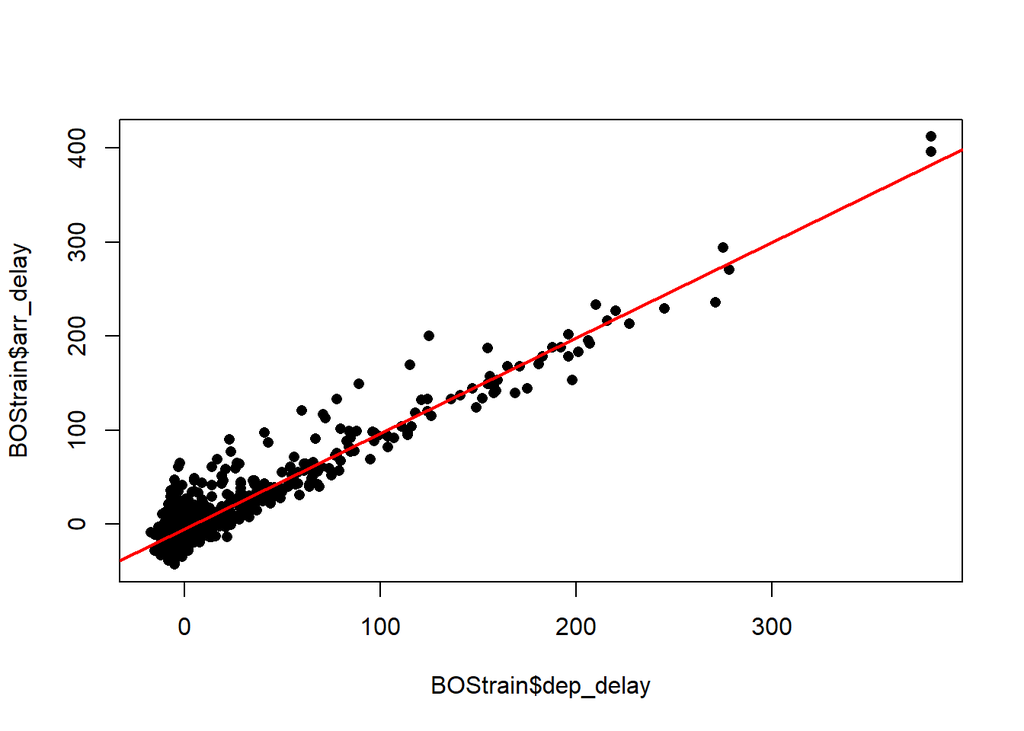

```r
plot(BOStrain$dep_delay,BOStrain$arr_delay,pch=16)
abline(a=modele_simple$coef[1], b=modele_simple$coef[2], col=2, lwd=2)
```

**Exercice.** Quel est le pourcentage de la variabilité dans le délai à l’arrivée qui est expliqué par le délai au décollage ?

Si ce modèle simple était utilisé pour prédire `arr_delay`, nous pourrions nous attendre à une erreur quadratique moyenne de prédiction valant :

```r
mse_simple <- RMSEp(obs = BOStest$arr_delay,
                    pred = predict(object = modele_simple, newdata = BOStest))^2
mse_simple
```

```
## [1] 274.7946
```

**On retourne maintenant à la théorie.**

# Régression linéaire multiple

Voyons si nous pouvons améliorer le modèle en incluant plus de variables. Dans un premier temps, mettons dans le modèle toutes les variables potentielles que nous avons présélectionnées.

```r
modele_complet <- lm(arr_delay ~ dep_delay + origin + wknd + evening_rush_hour + seats +
                       dewp + humid + wind_sin + wind_cos + precip_indic + pressure + visib,
                     data = BOStrain, x=TRUE, y=TRUE)
summary(modele_complet)
```

```
##
## Call:
## lm(formula = arr_delay ~ dep_delay + origin + wknd + evening_rush_hour +
##     seats + dewp + humid + wind_sin + wind_cos + precip_indic +
##     pressure + visib, data = BOStrain, x = TRUE, y = TRUE)
##
## Residuals:
##     Min      1Q  Median      3Q     Max
## -33.031  -9.888  -2.413   5.713  80.313
##
## Coefficients:
##                         Estimate Std. Error t value Pr(>|t|)
## (Intercept)           535.730788 111.009187   4.826 1.66e-06 ***
## dep_delay               1.006098   0.011712  85.900  < 2e-16 ***
## originJFK              -2.501966   1.364594  -1.833  0.06710 .
## originLGA               2.588266   1.558698   1.661  0.09719 .
## wkndTRUE               -4.112111   1.436541  -2.863  0.00431 **
## evening_rush_hourTRUE   6.226516   1.993399   3.124  0.00185 **
## seats                  -0.040932   0.008438  -4.851 1.47e-06 ***
## dewp                    0.097258   0.111605   0.871  0.38377
## humid                  -0.045634   0.045676  -0.999  0.31806
## wind_sin                0.240598   0.097973   2.456  0.01427 *
## wind_cos               -0.096055   0.079327  -1.211  0.22630
## precip_indicTRUE       16.863974   5.910781   2.853  0.00444 **
## pressure               -0.525927   0.108573  -4.844 1.52e-06 ***
## visib                  -0.614765   0.684937  -0.898  0.36969
## ---
## Signif. codes:  0 '***' 0.001 '**' 0.01 '*' 0.05 '.' 0.1 ' ' 1
##
## Residual standard error: 15.04 on 810 degrees of freedom
## Multiple R-squared:  0.916,  Adjusted R-squared:  0.9146
## F-statistic: 679.4 on 13 and 810 DF,  p-value: < 2.2e-16
```

*Exercice* Quel pourcentage de la variabilité observée dans `arr_delay` est expliquée par le modèle?

Nous retrouvons des effets vus dans les graphiques exploratoires.

Par exemple, le coefficient pour la variable `evening_rush_hour` est positif et fortement significatif. Ainsi, un départ pendant l’heure de pointe de fin de journée est associé à des des délais de retard plus grands.

**Exercice.** Interpréter les coefficients estimés pour les variables `seats` et `wknd` dans le contexte du problème.

Pour tester si la variable `origin` a un impact globalement, il faut faire un test simultanément sur ses deux paramètres. Voici une façon de réaliser ce test.

```r
Anova(modele_complet, type = 3)
```

```
## Anova Table (Type III tests)
##
## Response: arr_delay
##                    Sum Sq  Df   F value    Pr(>F)
## (Intercept)          5269   1   23.2903 1.665e-06 ***
## dep_delay         1669305   1 7378.8376 < 2.2e-16 ***
## origin               2526   2    5.5828  0.003908 **
## wknd                 1854   1    8.1940  0.004311 **
## evening_rush_hour    2207   1    9.7567  0.001850 **
## seats                5324   1   23.5321 1.473e-06 ***
## dewp                  172   1    0.7594  0.383768
## humid                 226   1    0.9981  0.318061
## wind_sin             1364   1    6.0308  0.014268 *
## wind_cos              332   1    1.4662  0.226295
## precip_indic         1842   1    8.1401  0.004440 **
## pressure             5308   1   23.4644 1.525e-06 ***
## visib                 182   1    0.8056  0.369692
## Residuals          183245 810
## ---
## Signif. codes:  0 '***' 0.001 '**' 0.01 '*' 0.05 '.' 0.1 ' ' 1
```

Pour les variables numériques ou catégorique à 2 modalités, les tests rapportés dans ce tableau sont équivalents aux tests précédents (même seuils observés). Pour la variable `origin`, il s’agit d’un test global. Le très petit seuil observé nous indique que l’effet de la variable `origin` est significatif.

Pour le premier vol de la base de données test

```r
(new.dat <- BOStest[1,])
```

```
##      origin           time_hour tailnum year month day dep_time
## 1345    LGA 2013-07-29 20:00:00  N951UW 2013     7  29     1949
##      sched_dep_time dep_delay arr_time sched_arr_time arr_delay carrier
## 1345           2000       -11     2045           2112       -27      US
##      flight dest air_time distance hour minute seats dewp humid wind_dir
## 1345   2142  BOS       35      184   20      0    20   50 35.03      270
##      wind_speed precip pressure visib week_day  wknd evening_rush_hour
## 1345    11.5078      0   1017.7    10    lundi FALSE             FALSE
##      wind_sin      wind_cos precip_indic
## 1345 -11.5078 -2.113879e-15        FALSE
```

quel délai à l’arrivée serait raisonnable selon le modèle?

**Exercice.** Donner un intervalle de confiance au niveau 95% pour le délai moyen à l’arrivée dans ces conditions. Donner également un intervalle de confiance pour le délai à l’arrivée d’un vol en particulier avec ces conditions. Est-ce que la vraie valeur observée se trouve dans ce dernier intervalle de confiance?

**Exercice** Tracer un nuage de points des prévisions en fonction des observations dans l’échantillon test. Est-ce que le modèle semble bon?

Maintenant, mesurons la qualité de la prédiction de ce modèle pour des nouveaux vols de New York vers Boston en juillet.

```r
mse_complet <- RMSEp(obs = BOStest$arr_delay,
                     pred = predict(object = modele_complet, newdata = BOStest))^2
mse_complet
```

```
## [1] 205.8873
```

Cet indice a diminué comparativement au modèle de régression simple (205.89 versus 274.79).

Voyons si effectuer une sélection de variables améliore davantage les prévisions.

## Sélection de variables

### Sélection de variables par sélection de sous-modèles

Ajustons tous les sous-modèles possibles. (Cette étape prend environ 5 minutes à rouler sur mon ordinateur.)

```r
all_possible <- ols_step_all_possible(modele_complet)
```

Le meilleur modèle selon le critère du AIC est le suivant.

```r
as.data.frame(all_possible[all_possible$aic == min(all_possible$aic), ])
```

```
##      mindex n
## 3827   3797 9
##                                                                                 predictors
## 3827 dep_delay origin wknd evening_rush_hour seats wind_sin wind_cos precip_indic pressure
##        rsquare      adjr   predrsq      cp      aic     sbic      sbc
## 3827 0.9157934 0.9147577 0.9128745 7.91663 6817.592 4477.479 6874.162
##          msep      fpe        apc       hsp
## 3827 228.7055 228.6691 0.08627553 0.2778933
```

Ce modèle contient 9 des 12 variables de départ.

**Exercice.** Ajustez ce modèle et nommez le `modele_select`.

**Exercice.** Est-ce que ce modèle est meilleur que les précédents pour prédire les délais d’arrivée de nouveaux vols entre New York et Boston en juillet? Utilisez la fonction `RMSEp` pour comparer les observations dans l’échantillon test et les prévisions obtenues avec la fonction `predict` et le modèle choisi.

On trouve que l’erreur quadratique moyenne de prédiction a légèrement diminué comparativement au modèle complet (205.29 versus 205.89). On a donc un modèle plus simple et meilleur !

**Exercice.** Quel est le meilleur modèle selon le critère du coefficient de détermination ajusté `adjr`?

```r
as.data.frame(all_possible[all_possible$adjr == max(all_possible$adjr), ])
```

```
##      mindex n
## 3827   3797 9
##                                                                                 predictors
## 3827 dep_delay origin wknd evening_rush_hour seats wind_sin wind_cos precip_indic pressure
##        rsquare      adjr   predrsq      cp      aic     sbic      sbc
## 3827 0.9157934 0.9147577 0.9128745 7.91663 6817.592 4477.479 6874.162
##          msep      fpe        apc       hsp
## 3827 228.7055 228.6691 0.08627553 0.2778933
```

### Lasso

Ajustons un modèle de régression lasso sur nos données d’entraînement, en considérant les mêmes variables que celles dans le modèle complet.

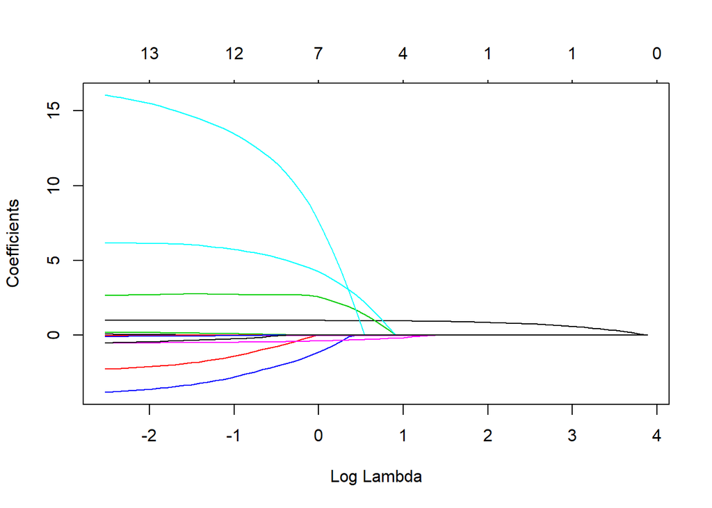

```r
modele_lasso <- glmnet(x = modele_complet$x[, -1], y = modele_complet$y, family = "gaussian", alpha = 1)
plot(modele_lasso, xvar = "lambda")
```

Le poids associé au terme de régularisation est choisi par validation croisée à 10 plis.

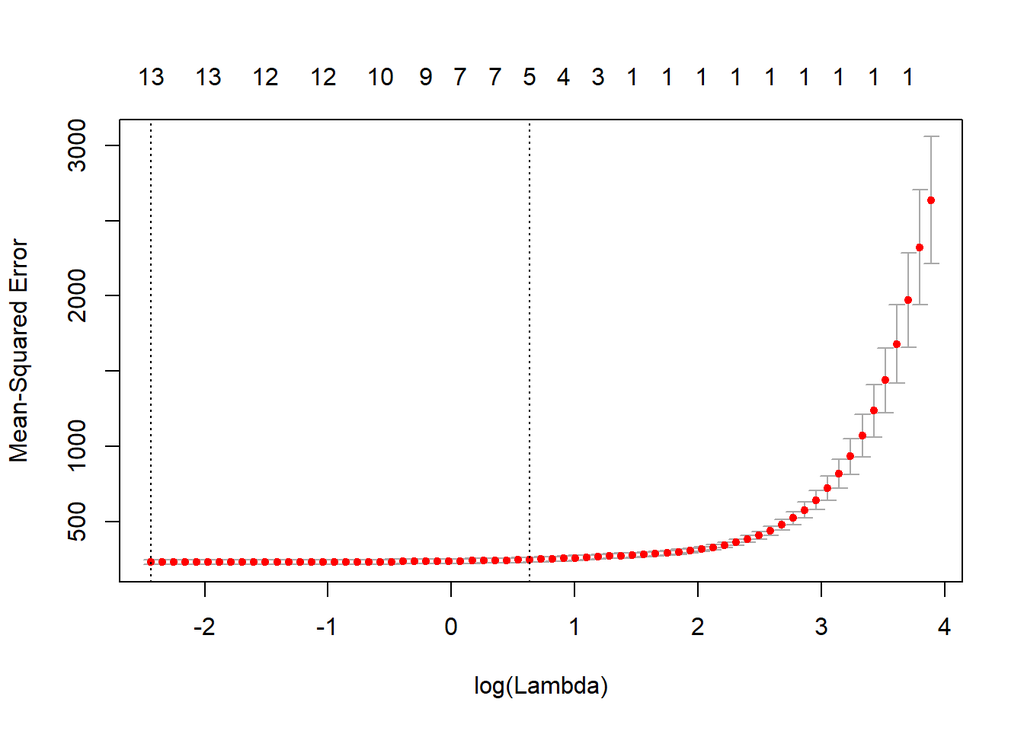

```r
set.seed(413) # pour avoir des résultats réplicables
cv_out <- cv.glmnet(x = modele_complet$x[, -1], y = modele_complet$y, family = "gaussian", alpha = 1)
plot(cv_out)
```

```r
best_lam <- cv_out$lambda.1se
log(best_lam)
```

```
## [1] 0.6332249
```

```r
coef(modele_lasso, s = best_lam)
```

```
## 14 x 1 sparse Matrix of class "dgCMatrix"
##                                  1
## (Intercept)           264.12876942
## dep_delay               0.97153068
## originJFK               .
## originLGA               1.09248667
## wkndTRUE                .
## evening_rush_hourTRUE   1.71039296
## seats                  -0.02001853
## dewp                    .
## humid                   .
## wind_sin                .
## wind_cos                .
## precip_indicTRUE        .
## pressure               -0.26321222
## visib                   .
```

Dans cet exemple, la régression lasso propose de conserver seulement 5 variables explicatives. Par contre l’erreur quadratique moyenne remonte:

```r
modele_lasso <- lm(arr_delay ~ dep_delay + origin + evening_rush_hour + seats + pressure, data = BOStrain)
summary(modele_lasso)
```

```
##
## Call:
## lm(formula = arr_delay ~ dep_delay + origin + evening_rush_hour +
##     seats + pressure, data = BOStrain)
##
## Residuals:
##     Min      1Q  Median      3Q     Max
## -36.731 -10.056  -2.761   6.084  79.149
##
## Coefficients:
##                         Estimate Std. Error t value Pr(>|t|)
## (Intercept)           493.595755 109.616191   4.503 7.68e-06 ***
## dep_delay               1.009884   0.011670  86.537  < 2e-16 ***
## originJFK              -1.565630   1.323204  -1.183 0.237070
## originLGA               3.593414   1.510344   2.379 0.017579 *
## evening_rush_hourTRUE   6.831032   1.970630   3.466 0.000555 ***
## seats                  -0.038244   0.008475  -4.513 7.34e-06 ***
## pressure               -0.488798   0.107771  -4.536 6.61e-06 ***
## ---
## Signif. codes:  0 '***' 0.001 '**' 0.01 '*' 0.05 '.' 0.1 ' ' 1
##
## Residual standard error: 15.2 on 817 degrees of freedom
## Multiple R-squared:  0.9134, Adjusted R-squared:  0.9128
## F-statistic:  1437 on 6 and 817 DF,  p-value: < 2.2e-16
```

```r
mse_lasso <- RMSEp(obs = BOStest$arr_delay,
                   pred = predict(object = modele_lasso, newdata = BOStest))^2
mse_lasso
```

```
## [1] 218.8065
```

#### Résumé des résultats pour la modélisation de `arr_delay`

```r
resume_mod_arr_delay <-
data.frame(AIC = c(AIC(modele_simple), AIC(modele_complet), AIC(modele_select),AIC(modele_lasso)),
RMSEtest = sqrt(c(mse_simple, mse_complet, mse_select, mse_lasso)))
rownames(resume_mod_arr_delay) <- c("modèle simple", "modèle complet", "modèle avec sélection de variables",
"modèle avec sélection LASSO")
resume_mod_arr_delay
```

```
##                                         AIC RMSEtest
## modèle simple                      6919.287 16.57693
## modèle complet                     6821.645 14.34877
## modèle avec sélection de variables 6817.592 14.32802
## modèle avec sélection LASSO        6832.462 14.79211
```